# Tarea 6: Mas bootstrap

```r
library(tidyr)
library(estcomp)
library(janitor)
library(tidyverse)
library(boot)
library(abind)
```

## Pregunta 1

Consideramos la siguiente muestra de los datos de ENLACE:

```r
set.seed(1983)
enlace_sample <- enlacep_2013 %>%
    janitor::clean_names() %>%
    mutate(id = 1:n()) %>%
    select(id, cve_ent, turno, tipo, mat_3 = punt_mat_3,
        n_eval_3 = alum_eval_3) %>%
    na.omit() %>%
    filter(mat_3 > 0, n_eval_3 > 0) %>%
    group_by(cve_ent) %>%
    sample_frac(size = 0.1) %>%
    ungroup()
```

Visualizamos los datos

```r
head(enlace_sample)
```

| id | cve_ent | turno | tipo | mat_3 | n_eval_3 |
| --- | --- | --- | --- | --- | --- |
| 579 | 01 | VESPERTINO | GENERAL | 570 | 19 |
| 94 | 01 | MATUTINO | GENERAL | 536 | 10 |
| 149 | 01 | MATUTINO | GENERAL | 487 | 24 |
| 140 | 01 | MATUTINO | GENERAL | 528 | 27 |
| 502 | 01 | VESPERTINO | GENERAL | 489 | 15 |
| 80 | 01 | MATUTINO | GENERAL | 568 | 36 |

```r
head(enlacep_2013)
```

| CVE_ENT | NOM_ENT | CCT | TURNO | ESCUELA | TIPO | CVE_MUN | NOM_MUN | CVE_LOC | NOM_LOC | PUNT_ESP_3 | PUNT_MAT_3 | PUNT_FCE_3 | PUNT_ESP_4 | PUNT_MAT_4 | PUNT_FCE_4 | PUNT_ESP_5 | PUNT_MAT_5 | PUNT_FCE_5 | PUNT_ESP_6 | PUNT_MAT_6 | PUNT_FCE_6 | POR_N1_ESP_3 | POR_N2_ESP_3 | POR_N3_ESP_3 | POR_N4_ESP_3 | POR_N1_ESP_4 | POR_N2_ESP_4 | POR_N3_ESP_4 | POR_N4_ESP_4 | … |
| --- | --- | --- | --- | --- | --- | --- | --- | --- | --- | --- | --- | --- | --- | --- | --- | --- | --- | --- | --- | --- | --- | --- | --- | --- | --- | --- | --- | --- | --- | --- |
| 01 | AGUASCALIENTES | 01DPR0001V | MATUTINO | RODRIGO RINCON GALLARDO | GENERAL | 007 | RINCON DE ROMOS | 0001 | RINCON DE ROMOS | 513 | 536 | 459 | 477 | 489 | 443 | 475 | 513 | 424 | 468 | 592 | 410 | 7.5% | 60.0% | 32.5% | 0.0% | 30.0% | 52.5% | 17.5% | 0.0% | … |
| 01 | AGUASCALIENTES | 01DPR0002U | MATUTINO | ANTONIO VENTURA MEDINA | GENERAL | 008 | SAN JOSE DE GRACIA | 0001 | SAN JOSE DE GRACIA | 472 | 472 | 404 | 547 | 586 | 458 | 462 | 484 | 412 | 475 | 553 | 440 | 17.1% | 77.1% | 5.7% | 0.0% | 14.0% | 32.0% | 52.0% | 2.0% | … |
| 01 | AGUASCALIENTES | 01DPR0003T | VESPERTINO | BENIGNO CHAVEZ | GENERAL | 005 | JESUS MARIA | 0001 | JESUS MARIA | 496 | 526 | 426 | 486 | 549 | 449 | 506 | 575 | 463 | 541 | 588 | 498 | 18.9% | 51.1% | 30.0% | 0.0% | 29.3% | 50.0% | 18.3% | 2.4% | … |
| 01 | AGUASCALIENTES | 01DPR0005R | MATUTINO | 15 DE SEPTIEMBRE | GENERAL | 001 | AGUASCALIENTES | 0001 | AGUASCALIENTES | 543 | 586 | 495 | 567 | 582 | 508 | 588 | 583 | 534 | 576 | 573 | 530 | 11.0% | 42.5% | 42.5% | 4.1% | 12.9% | 38.6% | 31.4% | 17.1% | … |
| 01 | AGUASCALIENTES | 01DPR0006Q | MATUTINO | TIERRA SOLIDARIA | GENERAL | 001 | AGUASCALIENTES | 0001 | AGUASCALIENTES | 554 | 560 | 506 | 569 | 588 | 507 | 528 | 552 | 465 | 590 | 635 | 526 | 0.0% | 66.7% | 23.3% | 10.0% | 3.4% | 51.7% | 34.5% | 10.3% | … |
| 01 | AGUASCALIENTES | 01DPR0007P | MATUTINO | MIGUEL ANGEL BARBERENA VEGA | GENERAL | 001 | AGUASCALIENTES | 0001 | AGUASCALIENTES | 505 | 546 | 460 | 493 | 490 | 453 | 534 | 557 | 486 | 543 | 573 | 504 | 13.8% | 63.1% | 21.5% | 1.5% | 24.3% | 51.4% | 21.6% | 2.7% | … |

### Inciso A

Selecciona el subconjunto de datos de Chiapas (clave de entidad 07):

```r
enlace_sample_chiapas <- enlace_sample  %>%
  filter(cve_ent=="07")

enlace_chiapas <- enlacep_2013 %>%
  filter(CVE_ENT=="07")

#Respuesta
nrow(enlace_sample_chiapas)
```

```
## [1] 635
```

```r
#Todas las escuelas de chiapas
nrow(enlace_chiapas)
```

```
## [1] 7005
```

### Inciso B

Calcula el estimador plug-in para la mediana de las calificaciones de matemáticas (en Chiapas).

```r
mediana_muestra <- median(enlace_sample_chiapas$mat_3, na.rm = TRUE)
print(mediana_muestra)
```

```
## [1] 589
```

```r
#Que tan lejos está la mediana de la muestra a la de la población
median(enlace_chiapas$PUNT_MAT_3, na.rm = TRUE)
```

```
## [1] 571
```

### Inciso C

Calcula el estimador bootstrap del error estándar y construye un intrvalo de confianza normal. Debes 1) tomar muestras bootstrap con reemplazo del subconjunto de datos de Chiapas, 2) calcular la mediana en cada una de las muestras y 3) calcular la desviación estándar de las medianas de 2).

```r
muestra_mediana <- function(df) {
    #1) tomar muestras bootstrap con reemplazo del subconjunto de datos de Chiapas
    muestra <- sample_n(df, nrow(df), replace =TRUE)
    #2) calcular la mediana en cada una de las muestras
    median(muestra$mat_3, na.rm = TRUE)
}

error_boot <- rerun(1000, muestra_mediana(enlace_sample_chiapas)) %>%
  flatten_dbl()

#3) calcular la desviación estándar de las medianas
sd <- sd(error_boot)
print(sd)
```

```
## [1] 10.83297
```

```r
#Intervalo de confianza
mean <- mediana_muestra
li_normal <- round(mean - 1.96 * sd(error_boot), 3)
ls_normal <- round(mean + 1.96 * sd(error_boot), 3)
c(li_normal, ls_normal)
```

```
## [1] 567.767 610.233
```

### Inciso D

Repite los pasos anteriores para la Ciudad de México (clave de entidad 09). Compara los intervalos de confianza.

```r
intervalo_estado <- function(enlace_sample, ent) {
  enlace_sample_edo <- enlace_sample  %>%
    filter(cve_ent==ent)

  mediana_muestra <- median(enlace_sample_edo$mat_3, na.rm = TRUE)

  muestra_mediana <- function(df) {
      #1) tomar muestras bootstrap con reemplazo del subconjunto de datos de Chiapas
      muestra <- sample_n(df, nrow(df), replace =TRUE)
      #2) calcular la mediana en cada una de las muestras
      median(muestra$mat_3, na.rm = TRUE)
  }

  error_boot <- rerun(1000, muestra_mediana(enlace_sample_edo)) %>%
    flatten_dbl()

  #3) calcular la desviación estándar de las medianas
  sd_patial <- sd(error_boot)

  #Intervalo de confianza
  mean <- mediana_muestra
  li_normal <- round(mean - 1.96 * sd_patial, 3)
  ls_normal <- round(mean + 1.96 * sd_patial, 3)
  c(li_normal, ls_normal)
}


intervalo_estado(enlace_sample, "07")
```

```
## [1] 567.236 610.764
```

```r
intervalo_estado(enlace_sample, "09")
```

```
## [1] 608.253 629.747
```

Es interesante que los intervalos se empalman. Es decir, es posible que la mediana de los dos estados sea la misma.

## Pregunta 2

Intervalos de confianza. En este ejercicio compararemos distintos intervalos de confianza para las medias de una exponencial.

Simula una muestra de tamaño 40 de una distribución exponencial(1/2).

```r
sim_exp <- rexp(40, (1/2))
```

### Inciso A

Calcula el estimador plug-in.

```r
mean <- mean(sim_exp)
mean
```

```
## [1] 1.690448
```

### Inciso B

Calcula intervalos: normal, de percentiles y BCA, presentalos en una tabla (para los BCA usa la función boot.ci() del paquete boot

```r
sim_exp <- rexp(40, 1/2)
my_mean <- function(x, ind) mean(x[ind])
boot_sim_exp <- boot(sim_exp, my_mean, R = 200)
ints <- boot.ci(boot_sim_exp, type = c("norm", "perc", "bca"))
ints
```

```
## BOOTSTRAP CONFIDENCE INTERVAL CALCULATIONS
## Based on 200 bootstrap replicates
##
## CALL :
## boot.ci(boot.out = boot_sim_exp, type = c("norm", "perc", "bca"))
##
## Intervals :
## Level      Normal             Percentile            BCa
## 95%   ( 1.525,  2.802 )   ( 1.591,  2.753 )   ( 1.612,  2.909 )
## Calculations and Intervals on Original Scale
## Some percentile intervals may be unstable
## Some BCa intervals may be unstable
```

“A mano”

```r
muestra_mean <- function(info) {
    sample(info,length(info), replace =TRUE) %>%
    mean(na.rm = TRUE)
}

error_boot <- rerun(200, muestra_mean(sim_exp)) %>%
  flatten_dbl()

sd_patial <- sd(error_boot)

#Intervalo de confianza (Normal)
li_normal <- round(mean - 1.96 * sd_patial, 3)
ls_normal <- round(mean + 1.96 * sd_patial, 3)
ic_norm <- c(li_normal, ls_normal)


#Percentiles
li_perc <- round(quantile(error_boot, probs = 0.025),3)
ls_perc <- round(quantile(error_boot, probs = 0.975),3)
ic_perc <- c(li_perc, ls_perc)


#BCA
boot_sim_exp <- boot(sim_exp, my_mean, R = 200)
bca_int <- boot.ci(boot_sim_exp, type = "bca")
li_bca <- round(bca_int[[4]][4], 3)
ls_bca <- round(bca_int[[4]][5], 3)
ic_bca <-  c(li_bca, ls_bca)

as.tibble(cbind(ic_norm, ic_perc, ic_bca))
```

| ic_norm | ic_perc | ic_bca |
| --- | --- | --- |
| 1.005 | 1.627 | 1.684 |
| 2.376 | 2.906 | 3.184 |

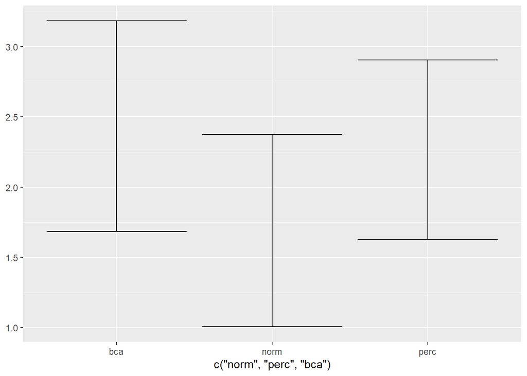

```r
ci_uno <- as.tibble(cbind(ic_norm, ic_perc, ic_bca))
t_uno <-  as.data.frame(t(ci_uno))

ggplot(t_uno, aes(x= c("norm", "perc","bca"))) +
geom_errorbar(aes(ymax = t_uno[,2], ymin=t_uno[,1]))
```

Repite los pasos anteriores 200 veces y grafica los intervalos, ¿cómo se comparan? Se acercan más los intervalos

```r
get_CI <- function() {
  sim_exp <- rexp(40, 1/2)
  muestra_mean <- function(info) {
      sample(info,length(info), replace =TRUE) %>%
      mean(na.rm = TRUE)
  }

  error_boot <- rerun(200, muestra_mean(sim_exp)) %>%
    flatten_dbl()

  sd_patial <- sd(error_boot)

  #Intervalo de confianza (Normal)
  li_normal <- round(mean - 1.96 * sd_patial, 3)
  ls_normal <- round(mean + 1.96 * sd_patial, 3)
  ic_norm <- c(li_normal, ls_normal)


  #Percentiles
  li_perc <- round(quantile(error_boot, probs = 0.025),3)
  ls_perc <- round(quantile(error_boot, probs = 0.975),3)
  ic_perc <- c(li_perc, ls_perc)


  #BCA
  boot_sim_exp <- boot(sim_exp, my_mean, R = 200)
  bca_int <- boot.ci(boot_sim_exp, type = "bca")
  li_bca <- round(bca_int[[4]][4], 3)
  ls_bca <- round(bca_int[[4]][5], 3)
  ic_bca <-  c(li_bca, ls_bca)

  as.tibble(cbind(ic_norm, ic_perc, ic_bca))
  as.data.frame(cbind(ic_norm, ic_perc, ic_bca))
}

CI_boot <- rerun(200,get_CI())
```

[output not shown]

```r
all.matrix <- abind(CI_boot, along=3)
prom_ci <- as.data.frame(apply(all.matrix, c(1,2), mean))
prom_ci
```

|  | ic_norm | ic_perc | ic_bca |
| --- | --- | --- | --- |
| 2.5% | 1.084765 | 1.472410 | 1.514885 |
| 97.5% | 2.296105 | 2.651115 | 2.797960 |

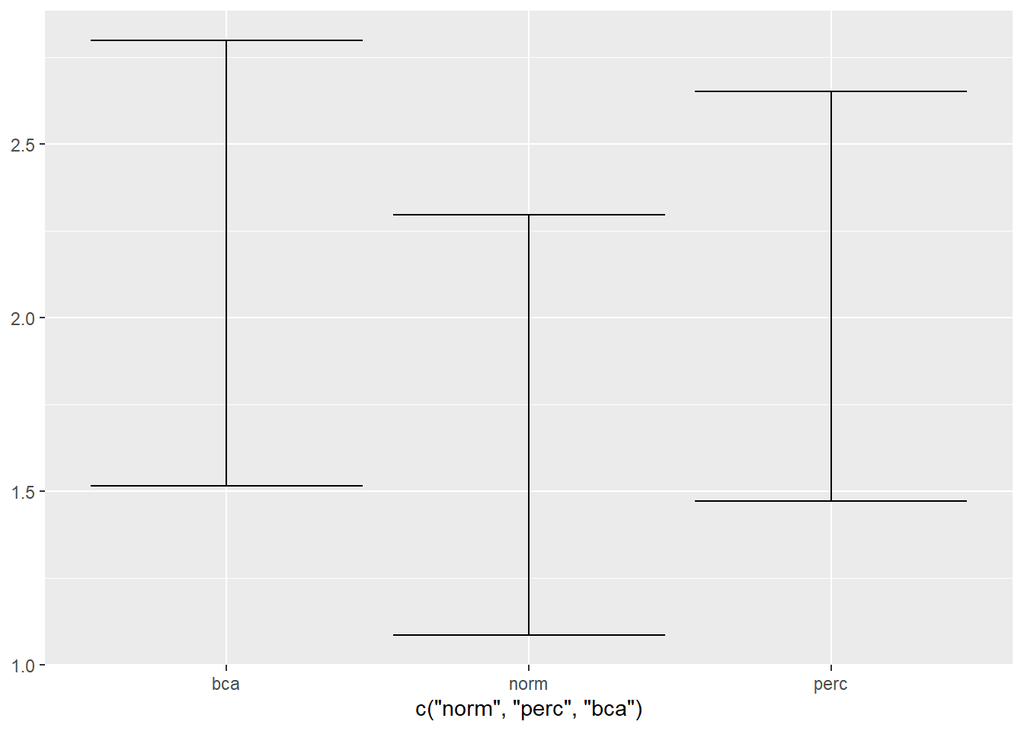

```r
t_prom <-  as.data.frame(t(prom_ci))

ggplot(t_prom, aes(x= c("norm", "perc","bca"))) +
  geom_errorbar(aes(ymax = t_prom[,2], ymin=t_prom[,1]))
```